# wallmart_pynb

## Business Problem:

The Management team at Walmart Inc. wants to analyze the customer purchase behavior (specifically, purchase amount) against the customer’s gender and the various other factors to help the business make better decisions. They want to understand if the spending habits differ between male and female customers: Do women spend more on Black Friday than men? (Assume 50 million customers are male and 50 million are female).

### Analytical Questions :

Q1. What is the Purchase Amount Distribution of Males and Females ?

Q2. What age group are spending more in Males and Females ?

Q3. What Product Categories are being ordered most with respect to those groups ?

Q4. Which Occupations does those Age Groups Belong to ?

Q5. What is the population distribution of age in different citites ?

Q6. Are the spenders married or single in majority?

Q7. Which products are being ordered by single and married people ?

Q8. Which of the two Genders in The data are actually spending more ?

- Generate Inferential Insights

```python
import pandas as pd
import numpy as np
import seaborn as sns
import matplotlib.pyplot as plt
```

```python
df = pd.read_csv('/content/drive/MyDrive/walmart_data.txt')
df
```

|  | User_ID | Product_ID | Gender | Age | Occupation | City_Category | Stay_In_Current_City_Years | Marital_Status | Product_Category | Purchase |
| --- | --- | --- | --- | --- | --- | --- | --- | --- | --- | --- |
| 0 | 1000001 | P00069042 | F | 0-17 | 10 | A | 2 | 0 | 3 | 8370 |
| 1 | 1000001 | P00248942 | F | 0-17 | 10 | A | 2 | 0 | 1 | 15200 |
| 2 | 1000001 | P00087842 | F | 0-17 | 10 | A | 2 | 0 | 12 | 1422 |
| 3 | 1000001 | P00085442 | F | 0-17 | 10 | A | 2 | 0 | 12 | 1057 |
| 4 | 1000002 | P00285442 | M | 55+ | 16 | C | 4+ | 0 | 8 | 7969 |
| ... | ... | ... | ... | ... | ... | ... | ... | ... | ... | ... |
| 550063 | 1006033 | P00372445 | M | 51-55 | 13 | B | 1 | 1 | 20 | 368 |
| 550064 | 1006035 | P00375436 | F | 26-35 | 1 | C | 3 | 0 | 20 | 371 |
| 550065 | 1006036 | P00375436 | F | 26-35 | 15 | B | 4+ | 1 | 20 | 137 |
| 550066 | 1006038 | P00375436 | F | 55+ | 1 | C | 2 | 0 | 20 | 365 |
| 550067 | 1006039 | P00371644 | F | 46-50 | 0 | B | 4+ | 1 | 20 | 490 |

550068 rows × 10 columns

```python
df.head()
```

|  | User_ID | Product_ID | Gender | Age | Occupation | City_Category | Stay_In_Current_City_Years | Marital_Status | Product_Category | Purchase |
| --- | --- | --- | --- | --- | --- | --- | --- | --- | --- | --- |
| 0 | 1000001 | P00069042 | F | 0-17 | 10 | A | 2 | 0 | 3 | 8370 |
| 1 | 1000001 | P00248942 | F | 0-17 | 10 | A | 2 | 0 | 1 | 15200 |
| 2 | 1000001 | P00087842 | F | 0-17 | 10 | A | 2 | 0 | 12 | 1422 |
| 3 | 1000001 | P00085442 | F | 0-17 | 10 | A | 2 | 0 | 12 | 1057 |
| 4 | 1000002 | P00285442 | M | 55+ | 16 | C | 4+ | 0 | 8 | 7969 |

```python
df.info()
```

```
<class 'pandas.core.frame.DataFrame'>
RangeIndex: 550068 entries, 0 to 550067
Data columns (total 10 columns):
 #   Column                      Non-Null Count   Dtype
---  ------                      --------------   -----
 0   User_ID                     550068 non-null  int64
 1   Product_ID                  550068 non-null  object
 2   Gender                      550068 non-null  object
 3   Age                         550068 non-null  object
 4   Occupation                  550068 non-null  int64
 5   City_Category               550068 non-null  object
 6   Stay_In_Current_City_Years  550068 non-null  object
 7   Marital_Status              550068 non-null  int64
 8   Product_Category            550068 non-null  int64
 9   Purchase                    550068 non-null  int64
dtypes: int64(5), object(5)
memory usage: 42.0+ MB
```

```python
df.describe()
```

|  | User_ID | Occupation | Marital_Status | Product_Category | Purchase |
| --- | --- | --- | --- | --- | --- |
| count | 5.500680e+05 | 550068.000000 | 550068.000000 | 550068.000000 | 550068.000000 |
| mean | 1.003029e+06 | 8.076707 | 0.409653 | 5.404270 | 9263.968713 |
| std | 1.727592e+03 | 6.522660 | 0.491770 | 3.936211 | 5023.065394 |
| min | 1.000001e+06 | 0.000000 | 0.000000 | 1.000000 | 12.000000 |
| 25% | 1.001516e+06 | 2.000000 | 0.000000 | 1.000000 | 5823.000000 |
| 50% | 1.003077e+06 | 7.000000 | 0.000000 | 5.000000 | 8047.000000 |
| 75% | 1.004478e+06 | 14.000000 | 1.000000 | 8.000000 | 12054.000000 |
| max | 1.006040e+06 | 20.000000 | 1.000000 | 20.000000 | 23961.000000 |

```python
df.head(20)
```

|  | User_ID | Product_ID | Gender | Age | Occupation | City_Category | Stay_In_Current_City_Years | Marital_Status | Product_Category | Purchase |
| --- | --- | --- | --- | --- | --- | --- | --- | --- | --- | --- |
| 0 | 1000001 | P00069042 | F | 0-17 | 10 | A | 2 | 0 | 3 | 8370 |
| 1 | 1000001 | P00248942 | F | 0-17 | 10 | A | 2 | 0 | 1 | 15200 |
| 2 | 1000001 | P00087842 | F | 0-17 | 10 | A | 2 | 0 | 12 | 1422 |
| 3 | 1000001 | P00085442 | F | 0-17 | 10 | A | 2 | 0 | 12 | 1057 |
| 4 | 1000002 | P00285442 | M | 55+ | 16 | C | 4+ | 0 | 8 | 7969 |
| 5 | 1000003 | P00193542 | M | 26-35 | 15 | A | 3 | 0 | 1 | 15227 |
| 6 | 1000004 | P00184942 | M | 46-50 | 7 | B | 2 | 1 | 1 | 19215 |
| 7 | 1000004 | P00346142 | M | 46-50 | 7 | B | 2 | 1 | 1 | 15854 |
| 8 | 1000004 | P0097242 | M | 46-50 | 7 | B | 2 | 1 | 1 | 15686 |
| 9 | 1000005 | P00274942 | M | 26-35 | 20 | A | 1 | 1 | 8 | 7871 |
| 10 | 1000005 | P00251242 | M | 26-35 | 20 | A | 1 | 1 | 5 | 5254 |
| 11 | 1000005 | P00014542 | M | 26-35 | 20 | A | 1 | 1 | 8 | 3957 |
| 12 | 1000005 | P00031342 | M | 26-35 | 20 | A | 1 | 1 | 8 | 6073 |
| 13 | 1000005 | P00145042 | M | 26-35 | 20 | A | 1 | 1 | 1 | 15665 |
| 14 | 1000006 | P00231342 | F | 51-55 | 9 | A | 1 | 0 | 5 | 5378 |
| 15 | 1000006 | P00190242 | F | 51-55 | 9 | A | 1 | 0 | 4 | 2079 |
| 16 | 1000006 | P0096642 | F | 51-55 | 9 | A | 1 | 0 | 2 | 13055 |
| 17 | 1000006 | P00058442 | F | 51-55 | 9 | A | 1 | 0 | 5 | 8851 |
| 18 | 1000007 | P00036842 | M | 36-45 | 1 | B | 1 | 1 | 1 | 11788 |
| 19 | 1000008 | P00249542 | M | 26-35 | 12 | C | 4+ | 1 | 1 | 19614 |

## **Data Exploration:**

```python
plt.style.use('seaborn-v0_8')

def set_plot(title, xlabel='', ylabel=''):
    plt.title(title, fontsize=14, fontweight='bold')
    plt.xlabel(xlabel)
    plt.ylabel(ylabel)
```

```python
df.isnull().sum()
```

|  | 0 |
| --- | --- |
| User_ID | 0 |
| Product_ID | 0 |
| Gender | 0 |
| Age | 0 |
| Occupation | 0 |
| City_Category | 0 |
| Stay_In_Current_City_Years | 0 |
| Marital_Status | 0 |
| Product_Category | 0 |
| Purchase | 0 |

**dtype:** int64

#### It was found that the data has no Null Values and its columns are in allignment with their data types.

```python
df.head(10)
```

|  | User_ID | Product_ID | Gender | Age | Occupation | City_Category | Stay_In_Current_City_Years | Marital_Status | Product_Category | Purchase |
| --- | --- | --- | --- | --- | --- | --- | --- | --- | --- | --- |
| 0 | 1000001 | P00069042 | F | 0-17 | 10 | A | 2 | 0 | 3 | 8370 |
| 1 | 1000001 | P00248942 | F | 0-17 | 10 | A | 2 | 0 | 1 | 15200 |
| 2 | 1000001 | P00087842 | F | 0-17 | 10 | A | 2 | 0 | 12 | 1422 |
| 3 | 1000001 | P00085442 | F | 0-17 | 10 | A | 2 | 0 | 12 | 1057 |
| 4 | 1000002 | P00285442 | M | 55+ | 16 | C | 4+ | 0 | 8 | 7969 |
| 5 | 1000003 | P00193542 | M | 26-35 | 15 | A | 3 | 0 | 1 | 15227 |
| 6 | 1000004 | P00184942 | M | 46-50 | 7 | B | 2 | 1 | 1 | 19215 |
| 7 | 1000004 | P00346142 | M | 46-50 | 7 | B | 2 | 1 | 1 | 15854 |
| 8 | 1000004 | P0097242 | M | 46-50 | 7 | B | 2 | 1 | 1 | 15686 |
| 9 | 1000005 | P00274942 | M | 26-35 | 20 | A | 1 | 1 | 8 | 7871 |

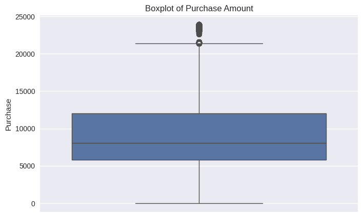

```python
plt.figure(figsize=(8,5))
sns.boxplot(data=df, y='Purchase')
plt.title('Boxplot of Purchase Amount')
plt.show()
```

```python
df['City_Category'].value_counts(normalize=True) * 100
```

| City_Category | proportion |
| --- | --- |
| B | 42.026259 |
| C | 31.118880 |
| A | 26.854862 |

**dtype:** float64

# Exploratory Data Analysis

Q1. What is the Purchase Amount Distribution of Males and Females ?

```python
males = df[df['Gender'] == 'M']
females = df[df['Gender'] == 'F']
```

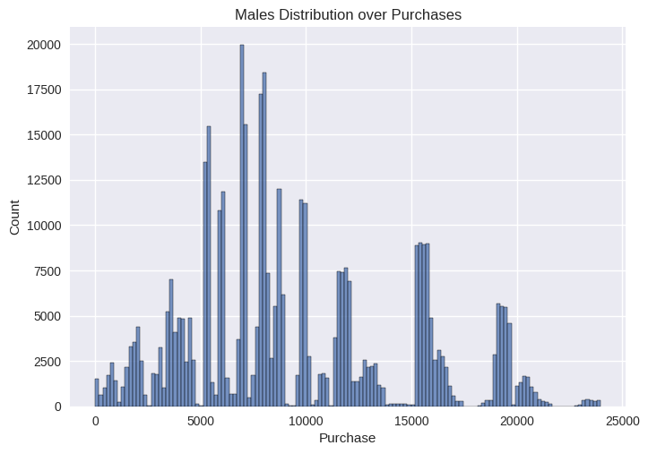

```python
sns.histplot(data=males, x='Purchase')
plt.title("Males Distribution over Purchases")

plt.show()
```

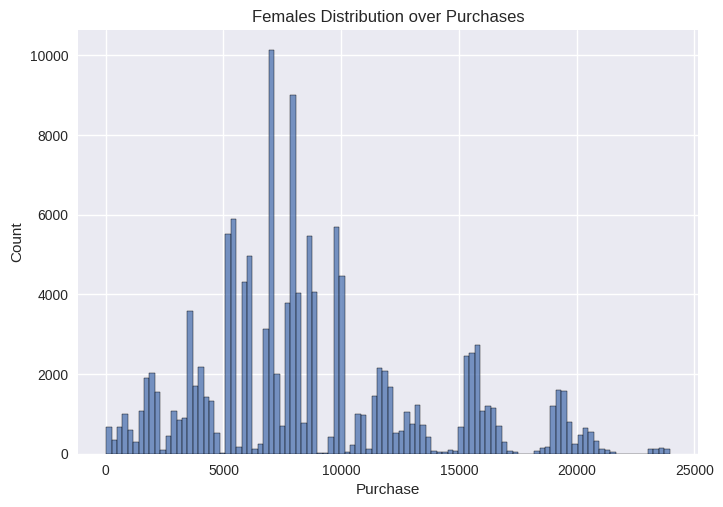

```python
sns.histplot(data=females, x='Purchase')
plt.title("Females Distribution over Purchases")

plt.show()
```

- Both of the data distribution are little bit Right skewed. So this distribution wont be effective for deeper inferential statistics.

### Since the purchase data is right-skewed, both mean and median were analyzed to ensure robust interpretation of spending behavior.

Q2. What age group are spending more in Males and Females ?

```python
data_distribution = df.groupby('Gender')['User_ID'].count().reset_index()
data_distribution['Percentage'] = (data_distribution['User_ID'] / data_distribution['User_ID'].sum()) * 100
data_distribution
```

|  | Gender | User_ID | Percentage |
| --- | --- | --- | --- |
| 0 | F | 135809 | 24.689493 |
| 1 | M | 414259 | 75.310507 |

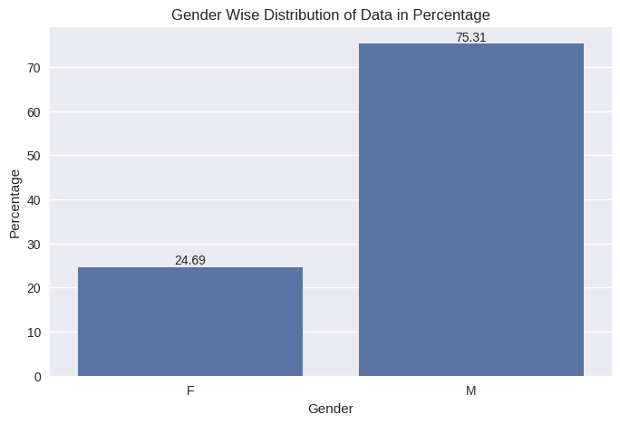

```python
plt.figure(figsize=(8,5))

ax = sns.barplot(data=data_distribution, x='Gender', y='Percentage')
plt.title("Gender Wise Distribution of Data in Percentage")

for container in ax.containers:
  ax.bar_label(container, fmt='%.2f')

plt.show()
```

- Population of Males in the data set is almost Three times the population of Females. This means that Males are about three times more spenders than females.

```python
males_age_grps = males.groupby('Age').agg({
    'Purchase': 'sum',
    'User_ID': 'count'
}).sort_values('Age').reset_index()
```

```python
females_age_grps = df[df['Gender'] == 'F'].groupby('Age').agg({'Purchase': 'sum', 'User_ID': 'count'}).reset_index()
```

```python
def millions(purchase):
    if purchase >= 1_000_000:
        return f"{purchase/1_000_000:.2f}"
    return purchase

males_age_grps['Purchase'] = males_age_grps['Purchase'].apply(millions)
males_age_grps['Purchase'] = males_age_grps['Purchase'].astype(float)
males_age_grps
```

|  | Age | Purchase | User_ID |
| --- | --- | --- | --- |
| 0 | 0-17 | 92.53 | 10019 |
| 1 | 18-25 | 708.37 | 75032 |
| 2 | 26-35 | 1588.79 | 168835 |
| 3 | 36-45 | 783.13 | 82843 |
| 4 | 46-50 | 304.14 | 32502 |
| 5 | 51-55 | 277.63 | 28607 |
| 6 | 55+ | 154.98 | 16421 |

```python
def millions(purchase):
    if purchase >= 1_000_000:
        return f"{purchase/1_000_000:.2f}"
    return purchase

females_age_grps['Purchase'] = females_age_grps['Purchase'].apply(millions)
females_age_grps['Purchase'] = females_age_grps['Purchase'].astype(float)
females_age_grps
```

|  | Age | Purchase | User_ID |
| --- | --- | --- | --- |
| 0 | 0-17 | 42.39 | 5083 |
| 1 | 18-25 | 205.48 | 24628 |
| 2 | 26-35 | 442.98 | 50752 |
| 3 | 36-45 | 243.44 | 27170 |
| 4 | 46-50 | 116.71 | 13199 |
| 5 | 51-55 | 89.47 | 9894 |
| 6 | 55+ | 45.78 | 5083 |

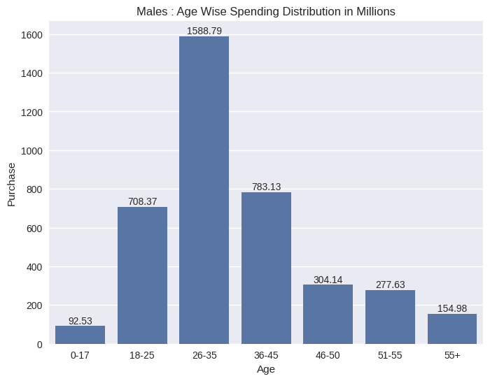

```python
plt.figure(figsize=(8,6))
ax = sns.barplot(data=males_age_grps,x='Age', y='Purchase')
plt.title('Males : Age Wise Spending Distribution in Millions')

for container in ax.containers:
  ax.bar_label(container, fmt='%.2f')

plt.show()
```

### From the histogram of Males we can say that:

1. The age group of 26-35 is the main revenue driver and should be the center target for all the marketing Campaigns.
2. The Age groups which are the far extremes like 0-17 and 55+ are of very low yield so we can pay less attention there.
3. The groups from 18-25 and 36-45 are potential age groups which can help us develop the business as well.

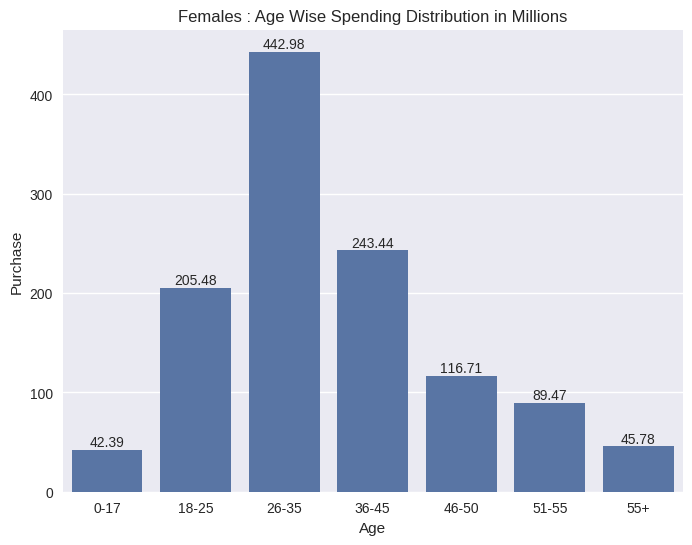

```python
plt.figure(figsize=(8,6))
ax = sns.barplot(data=females_age_grps,x='Age', y='Purchase')
plt.title('Females : Age Wise Spending Distribution in Millions')

for container in ax.containers:
  ax.bar_label(container, fmt='%.2f')

plt.show()
```

## The females histogram follows the same trend as Males. Only the thing is That it has lesser user population than males

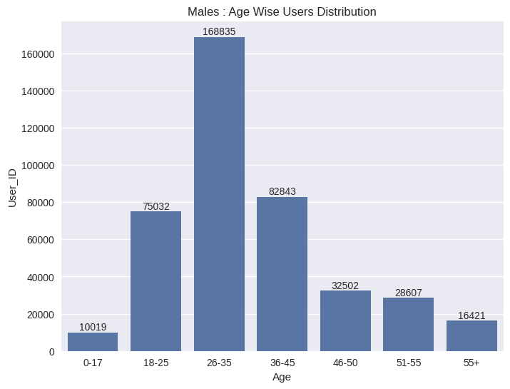

```python
plt.figure(figsize=(8,6))
ax = sns.barplot(data=males_age_grps,x='Age', y='User_ID')
plt.title('Males : Age Wise Users Distribution')

for container in ax.containers:
  ax.bar_label(container)

plt.show()
```

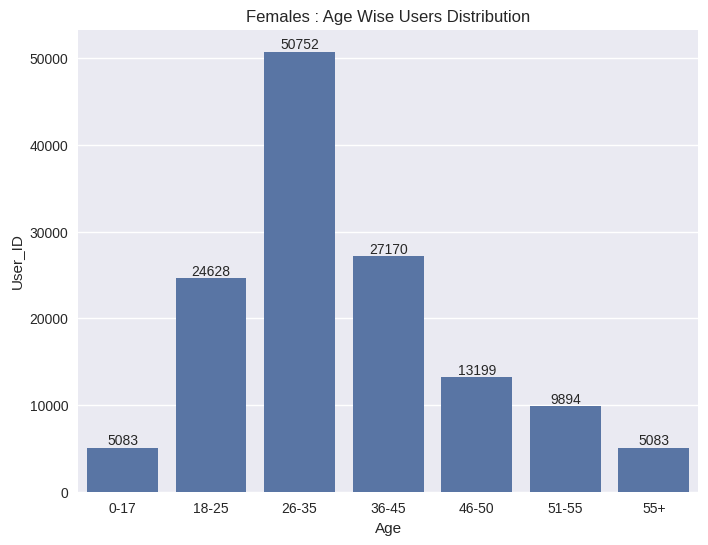

```python
plt.figure(figsize=(8,6))
ax = sns.barplot(data=females_age_grps,x='Age', y='User_ID')
plt.title('Females : Age Wise Users Distribution')

for container in ax.containers:
  ax.bar_label(container)

plt.show()
```

## The User count is more in those groups only so we can say that more number of people more amount of sales.

```python
males_age_grps["Avg_spend_per_user"] = ( males_age_grps['Purchase'] / males_age_grps['User_ID'] ) * 1000000
males_age_grps
```

|  | Age | Purchase | User_ID | Avg_spend_per_user |
| --- | --- | --- | --- | --- |
| 0 | 0-17 | 92.53 | 10019 | 9235.452640 |
| 1 | 18-25 | 708.37 | 75032 | 9440.905214 |
| 2 | 26-35 | 1588.79 | 168835 | 9410.311843 |
| 3 | 36-45 | 783.13 | 82843 | 9453.182526 |
| 4 | 46-50 | 304.14 | 32502 | 9357.577995 |
| 5 | 51-55 | 277.63 | 28607 | 9704.967316 |
| 6 | 55+ | 154.98 | 16421 | 9437.914865 |

```python
females_age_grps["Avg_spend_per_user"] = ( females_age_grps['Purchase'] / females_age_grps['User_ID'] ) * 1000000
females_age_grps
```

|  | Age | Purchase | User_ID | Avg_spend_per_user |
| --- | --- | --- | --- | --- |
| 0 | 0-17 | 42.39 | 5083 | 8339.563250 |
| 1 | 18-25 | 205.48 | 24628 | 8343.349034 |
| 2 | 26-35 | 442.98 | 50752 | 8728.325977 |
| 3 | 36-45 | 243.44 | 27170 | 8959.882223 |
| 4 | 46-50 | 116.71 | 13199 | 8842.336541 |
| 5 | 51-55 | 89.47 | 9894 | 9042.854255 |
| 6 | 55+ | 45.78 | 5083 | 9006.492229 |

```python
# We see that in both females and males the age groups 18-25,26-35,36-45 are most spending people.
```

## Q. What Product Categories are being ordered most with respect to those groups ?

```python
ages = ["18-25","26-35","36-45"]
df_age_grps = df[df['Age'].isin(ages)]
```

```python
percentage = (len(df_age_grps) / len(df)) * 100
```

```python
percentage
```

```
78.03762443916025
```

### We see that the three age alone contribute to 78% of the entire dataset.

```python
df_age_grps
```

|  | User_ID | Product_ID | Gender | Age | Occupation | City_Category | Stay_In_Current_City_Years | Marital_Status | Product_Category | Purchase |
| --- | --- | --- | --- | --- | --- | --- | --- | --- | --- | --- |
| 5 | 1000003 | P00193542 | M | 26-35 | 15 | A | 3 | 0 | 1 | 15227 |
| 9 | 1000005 | P00274942 | M | 26-35 | 20 | A | 1 | 1 | 8 | 7871 |
| 10 | 1000005 | P00251242 | M | 26-35 | 20 | A | 1 | 1 | 5 | 5254 |
| 11 | 1000005 | P00014542 | M | 26-35 | 20 | A | 1 | 1 | 8 | 3957 |
| 12 | 1000005 | P00031342 | M | 26-35 | 20 | A | 1 | 1 | 8 | 6073 |
| ... | ... | ... | ... | ... | ... | ... | ... | ... | ... | ... |
| 550059 | 1006025 | P00370853 | F | 26-35 | 1 | B | 1 | 0 | 19 | 48 |
| 550060 | 1006026 | P00371644 | M | 36-45 | 6 | C | 1 | 1 | 20 | 494 |
| 550061 | 1006029 | P00372445 | F | 26-35 | 1 | C | 1 | 1 | 20 | 599 |
| 550064 | 1006035 | P00375436 | F | 26-35 | 1 | C | 3 | 0 | 20 | 371 |
| 550065 | 1006036 | P00375436 | F | 26-35 | 15 | B | 4+ | 1 | 20 | 137 |

429260 rows × 10 columns

```python
df_age_grps_males = df_age_grps[df_age_grps['Gender'] == 'M']
df_age_grps_females = df_age_grps[df_age_grps['Gender'] == 'F']
```

```python
most_ordered_products_cat_males = df_age_grps_males.groupby('Product_Category')['User_ID'].count().reset_index()
most_ordered_products_cat_females = df_age_grps_females.groupby('Product_Category')['User_ID'].count().reset_index()
```

```python
top_5_ordered_products_cat_males = most_ordered_products_cat_males.sort_values('User_ID', ascending=False).reset_index(drop=True).head(5)
```

```python
top_5_ordered_products_cat_males
```

|  | Product_Category | User_ID |
| --- | --- | --- |
| 0 | 1 | 93562 |
| 1 | 5 | 87041 |
| 2 | 8 | 60961 |
| 3 | 11 | 15694 |
| 4 | 2 | 14074 |

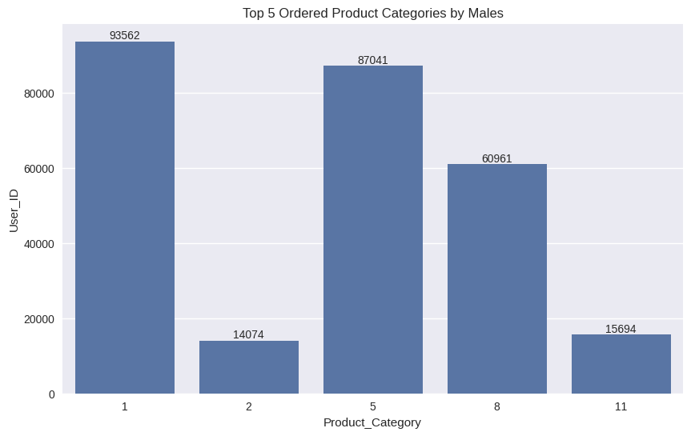

```python
plt.figure(figsize=(10,6))

ax = sns.barplot(data=top_5_ordered_products_cat_males, x='Product_Category', y='User_ID')
plt.title('Top 5 Ordered Product Categories by Males')

for container in ax.containers:
  ax.bar_label(container)

plt.show()
```

```python
top_5_ordered_products_cat_females = most_ordered_products_cat_females.sort_values('User_ID', ascending=False).head()
```

```python
top_5_ordered_products_cat_females
```

|  | Product_Category | User_ID |
| --- | --- | --- |
| 4 | 5 | 32331 |
| 7 | 8 | 24502 |
| 0 | 1 | 19297 |
| 2 | 3 | 4602 |
| 1 | 2 | 4194 |

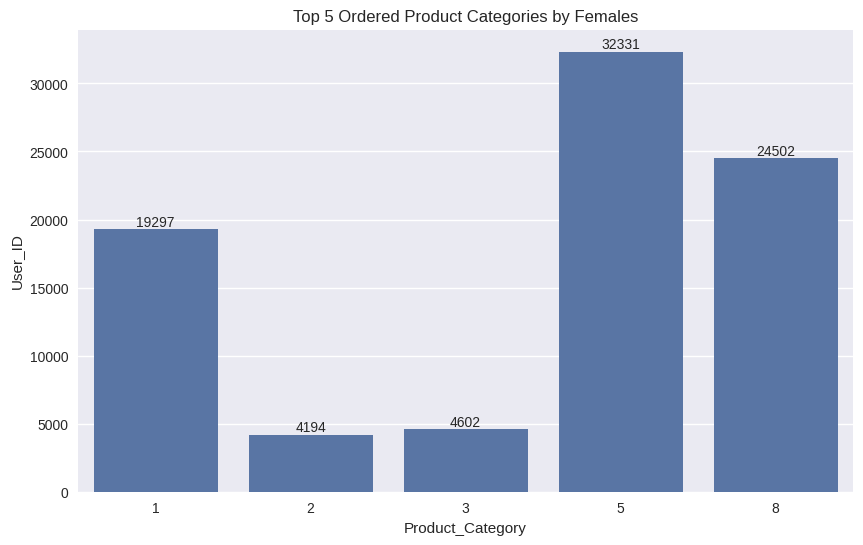

```python
plt.figure(figsize=(10,6))

ax = sns.barplot(data=top_5_ordered_products_cat_females, x='Product_Category', y='User_ID')
plt.title('Top 5 Ordered Product Categories by Females')

for container in ax.containers:
  ax.bar_label(container)

plt.show()
```

## We see that product categories 1,2,5,8 and most common in the top 78% of the dataset both in males and females.

```python
df[df['Product_Category'].isin([1,2,5,8])]
```

|  | User_ID | Product_ID | Gender | Age | Occupation | City_Category | Stay_In_Current_City_Years | Marital_Status | Product_Category | Purchase |
| --- | --- | --- | --- | --- | --- | --- | --- | --- | --- | --- |
| 1 | 1000001 | P00248942 | F | 0-17 | 10 | A | 2 | 0 | 1 | 15200 |
| 4 | 1000002 | P00285442 | M | 55+ | 16 | C | 4+ | 0 | 8 | 7969 |
| 5 | 1000003 | P00193542 | M | 26-35 | 15 | A | 3 | 0 | 1 | 15227 |
| 6 | 1000004 | P00184942 | M | 46-50 | 7 | B | 2 | 1 | 1 | 19215 |
| 7 | 1000004 | P00346142 | M | 46-50 | 7 | B | 2 | 1 | 1 | 15854 |
| ... | ... | ... | ... | ... | ... | ... | ... | ... | ... | ... |
| 545910 | 1006040 | P00184342 | M | 26-35 | 6 | B | 2 | 0 | 8 | 9855 |
| 545911 | 1006040 | P00193142 | M | 26-35 | 6 | B | 2 | 0 | 5 | 1962 |
| 545912 | 1006040 | P00029842 | M | 26-35 | 6 | B | 2 | 0 | 8 | 7852 |
| 545913 | 1006040 | P00106042 | M | 26-35 | 6 | B | 2 | 0 | 5 | 7159 |
| 545914 | 1006040 | P00217442 | M | 26-35 | 6 | B | 2 | 0 | 1 | 11640 |

429100 rows × 10 columns

```python
len(df[df['Product_Category'].isin([1,2,5,8])]) / len(df)
```

```
0.7800853712631893
```

```python
# How much revenue are they building ?

df_age_grps_top_prod_cats = df_age_grps[df_age_grps['Product_Category'].isin([1,2,5,8])]
top_prod_cat_revenue = df_age_grps_top_prod_cats.groupby('Product_Category')['Purchase'].sum().apply(millions).reset_index()
top_prod_cat_revenue
```

|  | Product_Category | Purchase |
| --- | --- | --- |
| 0 | 1 | 1527.05 |
| 1 | 2 | 203.40 |
| 2 | 5 | 739.48 |
| 3 | 8 | 635.23 |

```python
top_prod_cat_revenue['Purchase'] = top_prod_cat_revenue['Purchase'].astype(float)
top_prod_cat_revenue
```

|  | Product_Category | Purchase |
| --- | --- | --- |
| 0 | 1 | 1527.05 |
| 1 | 2 | 203.40 |
| 2 | 5 | 739.48 |
| 3 | 8 | 635.23 |

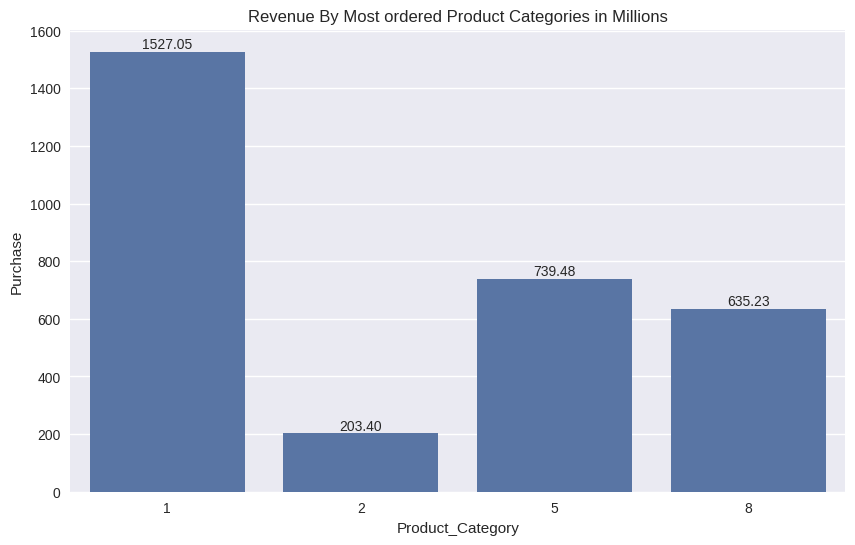

```python
plt.figure(figsize=(10,6))

ax = sns.barplot(data=top_prod_cat_revenue, x='Product_Category', y='Purchase')
plt.title("Revenue By Most ordered Product Categories in Millions")

for container in ax.containers:
  ax.bar_label(container, fmt='%.2f')

plt.show()
```

```python
df.groupby('Product_Category')['User_ID'].count().sort_values(ascending=False).head(5).reset_index()
```

|  | Product_Category | User_ID |
| --- | --- | --- |
| 0 | 5 | 150933 |
| 1 | 1 | 140378 |
| 2 | 8 | 113925 |
| 3 | 11 | 24287 |
| 4 | 2 | 23864 |

### Even though the people ordered 5th and 1st category in similar number. But the revenue generation has much difference. This is because maybe the product category 1 has higher prices compared to product category 1.

## Q. Which Occupations does those Age Groups Belong to ?

```python
df_age_grps
```

|  | User_ID | Product_ID | Gender | Age | Occupation | City_Category | Stay_In_Current_City_Years | Marital_Status | Product_Category | Purchase |
| --- | --- | --- | --- | --- | --- | --- | --- | --- | --- | --- |
| 5 | 1000003 | P00193542 | M | 26-35 | 15 | A | 3 | 0 | 1 | 15227 |
| 9 | 1000005 | P00274942 | M | 26-35 | 20 | A | 1 | 1 | 8 | 7871 |
| 10 | 1000005 | P00251242 | M | 26-35 | 20 | A | 1 | 1 | 5 | 5254 |
| 11 | 1000005 | P00014542 | M | 26-35 | 20 | A | 1 | 1 | 8 | 3957 |
| 12 | 1000005 | P00031342 | M | 26-35 | 20 | A | 1 | 1 | 8 | 6073 |
| ... | ... | ... | ... | ... | ... | ... | ... | ... | ... | ... |
| 550059 | 1006025 | P00370853 | F | 26-35 | 1 | B | 1 | 0 | 19 | 48 |
| 550060 | 1006026 | P00371644 | M | 36-45 | 6 | C | 1 | 1 | 20 | 494 |
| 550061 | 1006029 | P00372445 | F | 26-35 | 1 | C | 1 | 1 | 20 | 599 |
| 550064 | 1006035 | P00375436 | F | 26-35 | 1 | C | 3 | 0 | 20 | 371 |
| 550065 | 1006036 | P00375436 | F | 26-35 | 15 | B | 4+ | 1 | 20 | 137 |

429260 rows × 10 columns

```python
top_10_occ_in_age_grps_males = df_age_grps_males.groupby("Occupation")['User_ID'].count().sort_values(ascending=False).head(10).reset_index()
top_10_occ_in_age_grps_males['User_ID'] = top_10_occ_in_age_grps_males['User_ID'].astype(int)
```

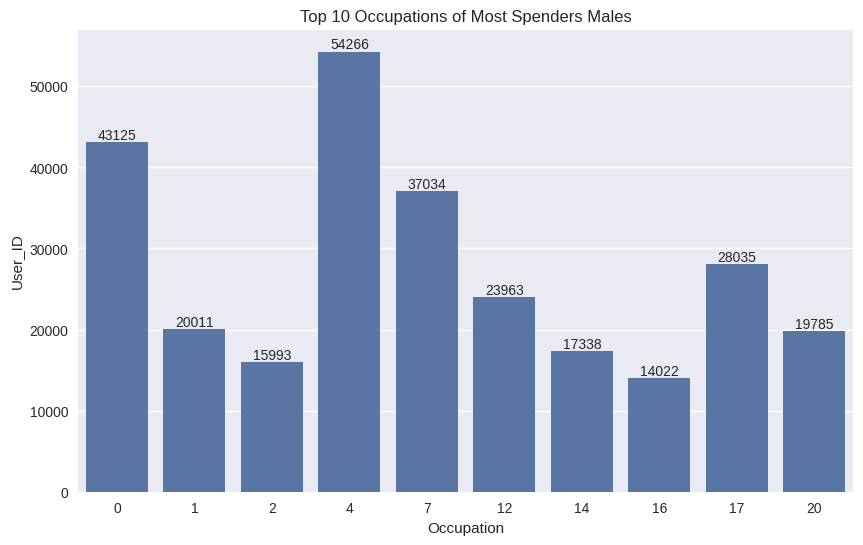

```python
plt.figure(figsize=(10,6))

ax = sns.barplot(top_10_occ_in_age_grps_males, x ='Occupation', y='User_ID')
plt.title("Top 10 Occupations of Most Spenders Males")

for container in ax.containers:
  ax.bar_label(container)

plt.show()
```

```python
top_10_occ_in_age_grps_females = df_age_grps_females.groupby("Occupation")['User_ID'].count().sort_values(ascending=False).head(10).reset_index()
top_10_occ_in_age_grps_females['User_ID'] = top_10_occ_in_age_grps_females['User_ID'].astype(int)
```

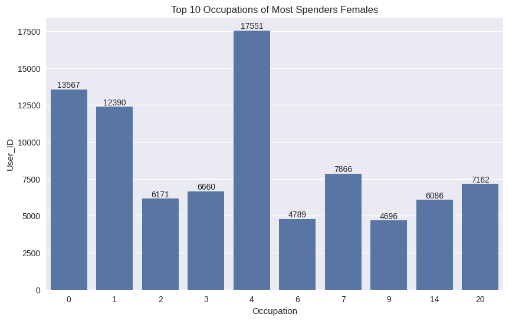

```python
plt.figure(figsize=(10,6))

ax = sns.barplot(top_10_occ_in_age_grps_females, x ='Occupation', y='User_ID')
plt.title("Top 10 Occupations of Most Spenders Females")

for container in ax.containers:
  ax.bar_label(container)

plt.show()
```

### Females show the similar pattern but with less magnitude. There is a gender gap in engagement.

## Q. What is the population distribution of age in different citites ?

```python
males
```

|  | User_ID | Product_ID | Gender | Age | Occupation | City_Category | Stay_In_Current_City_Years | Marital_Status | Product_Category | Purchase |
| --- | --- | --- | --- | --- | --- | --- | --- | --- | --- | --- |
| 4 | 1000002 | P00285442 | M | 55+ | 16 | C | 4+ | 0 | 8 | 7969 |
| 5 | 1000003 | P00193542 | M | 26-35 | 15 | A | 3 | 0 | 1 | 15227 |
| 6 | 1000004 | P00184942 | M | 46-50 | 7 | B | 2 | 1 | 1 | 19215 |
| 7 | 1000004 | P00346142 | M | 46-50 | 7 | B | 2 | 1 | 1 | 15854 |
| 8 | 1000004 | P0097242 | M | 46-50 | 7 | B | 2 | 1 | 1 | 15686 |
| ... | ... | ... | ... | ... | ... | ... | ... | ... | ... | ... |
| 550057 | 1006023 | P00370853 | M | 26-35 | 0 | C | 2 | 1 | 19 | 61 |
| 550058 | 1006024 | P00372445 | M | 26-35 | 12 | A | 0 | 1 | 20 | 121 |
| 550060 | 1006026 | P00371644 | M | 36-45 | 6 | C | 1 | 1 | 20 | 494 |
| 550062 | 1006032 | P00372445 | M | 46-50 | 7 | A | 3 | 0 | 20 | 473 |
| 550063 | 1006033 | P00372445 | M | 51-55 | 13 | B | 1 | 1 | 20 | 368 |

414259 rows × 10 columns

```python
city_wise_males_df = males.groupby(['City_Category', 'Age'])['User_ID'].count().reset_index().sort_values(['City_Category', 'User_ID'], ascending=[True, False])
city_wise_females_df = females.groupby(['City_Category', 'Age'])['User_ID'].count().reset_index().sort_values(['City_Category', 'User_ID'], ascending=[True, False])
```

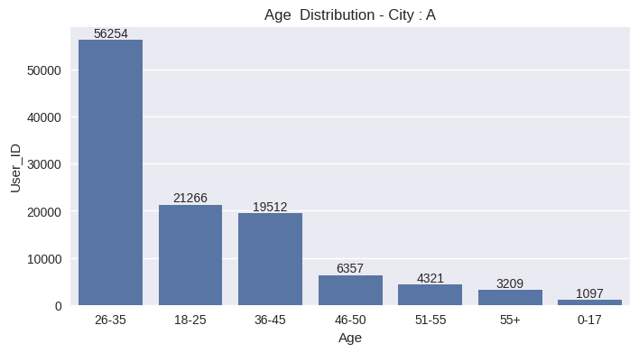

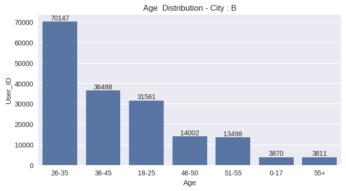

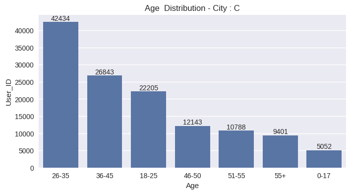

```python
# City wise Males distribution

cities = city_wise_males_df['City_Category'].unique()

for city in cities:
  plt.figure(figsize=(8,4))

  data = city_wise_males_df[city_wise_males_df['City_Category'] == city]

  ax = sns.barplot(data=data, x='Age', y='User_ID')

  plt.title(f"Age  Distribution - City : {city}")

  for container in ax.containers:
    ax.bar_label(container)

  plt.show()
```

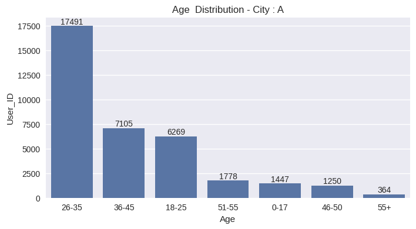

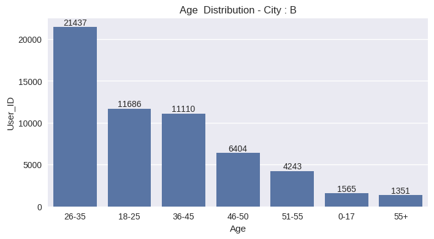

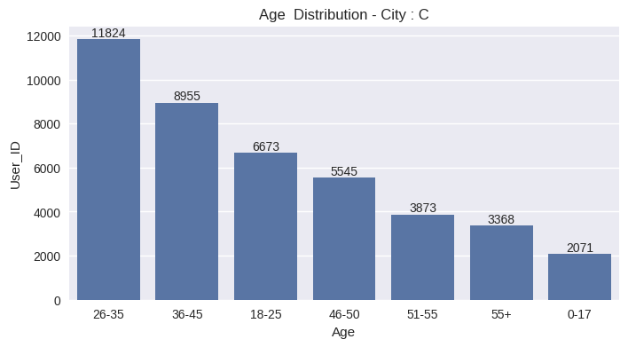

```python
# City wise females destribution

cities = city_wise_females_df['City_Category'].unique()

for city in cities:
  plt.figure(figsize=(8,4))

  data = city_wise_females_df[city_wise_females_df['City_Category'] == city]

  ax = sns.barplot(data=data, x='Age', y='User_ID')

  plt.title(f"Age  Distribution - City : {city}")

  for container in ax.containers:
    ax.bar_label(container)

  plt.show()
```

## Similar pattern for females but in lesser volume.

```python
# Revenue Wise

city_wise_males_revenue_df = males.groupby(['City_Category', 'Age'])['Purchase'].sum().reset_index().sort_values(['City_Category', 'Purchase'],ascending=[True, False])
city_wise_males_revenue_df['Purchase'] = city_wise_males_revenue_df['Purchase'].apply(millions).astype(float)

city_wise_females_revenue_df = females.groupby(['City_Category', 'Age'])['Purchase'].sum().reset_index().sort_values(['City_Category', 'Purchase'],ascending=[True, False])
city_wise_females_revenue_df['Purchase'] = city_wise_females_revenue_df['Purchase'].apply(millions).astype(float)
```

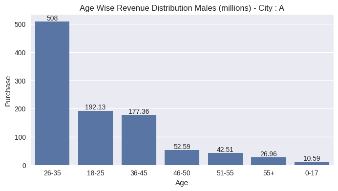

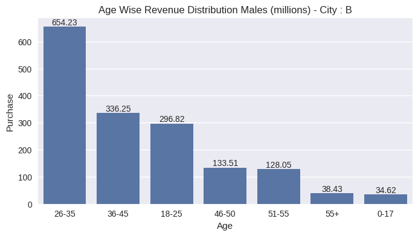

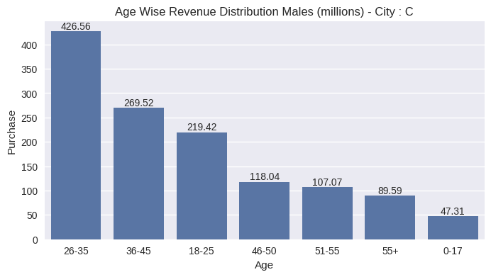

```python
# City wise Males distribution

cities = city_wise_males_revenue_df['City_Category'].unique()

for city in cities:
  plt.figure(figsize=(8,4))

  data = city_wise_males_revenue_df[city_wise_males_revenue_df['City_Category'] == city]

  ax = sns.barplot(data=data, x='Age', y='Purchase')

  plt.title(f"Age Wise Revenue Distribution Males (millions) - City : {city}")

  for container in ax.containers:
    ax.bar_label(container)

  plt.show()
```

## From the graph

1. Same age groups are highest spenders.
2. City B dominates in revenue
3. Age groups 46-50, 51-55 still contribute significantly.
4. 0-17 is negligible.

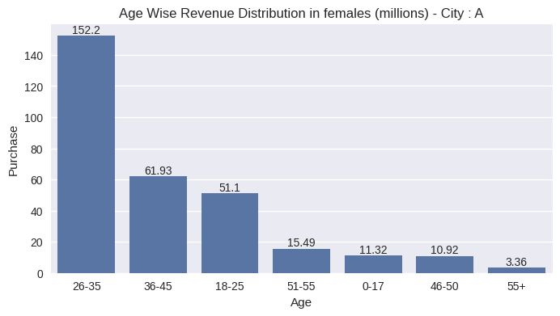

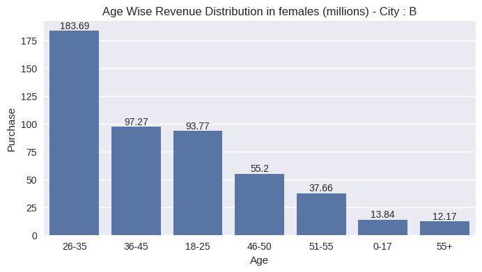

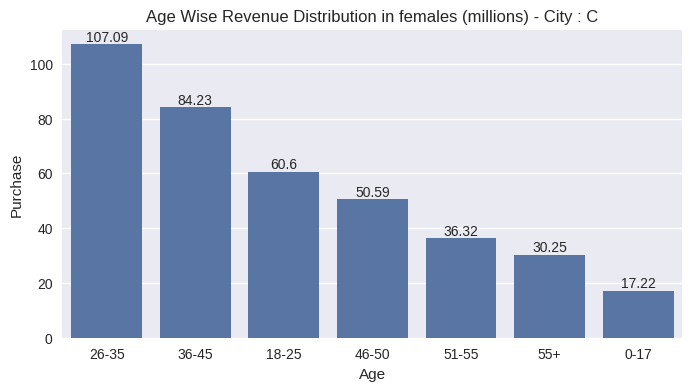

```python
# City wise Females distribution

cities = city_wise_females_revenue_df['City_Category'].unique()

for city in cities:
  plt.figure(figsize=(8,4))

  data = city_wise_females_revenue_df[city_wise_females_revenue_df['City_Category'] == city]

  ax = sns.barplot(data=data, x='Age', y='Purchase')

  plt.title(f"Age Wise Revenue Distribution in females (millions) - City : {city}")

  for container in ax.containers:
    ax.bar_label(container)

  plt.show()
```

### Similar patterns here as well.

## Q. Are the spenders married or single in majority?

```python
males
```

|  | User_ID | Product_ID | Gender | Age | Occupation | City_Category | Stay_In_Current_City_Years | Marital_Status | Product_Category | Purchase |
| --- | --- | --- | --- | --- | --- | --- | --- | --- | --- | --- |
| 4 | 1000002 | P00285442 | M | 55+ | 16 | C | 4+ | 0 | 8 | 7969 |
| 5 | 1000003 | P00193542 | M | 26-35 | 15 | A | 3 | 0 | 1 | 15227 |
| 6 | 1000004 | P00184942 | M | 46-50 | 7 | B | 2 | 1 | 1 | 19215 |
| 7 | 1000004 | P00346142 | M | 46-50 | 7 | B | 2 | 1 | 1 | 15854 |
| 8 | 1000004 | P0097242 | M | 46-50 | 7 | B | 2 | 1 | 1 | 15686 |
| ... | ... | ... | ... | ... | ... | ... | ... | ... | ... | ... |
| 550057 | 1006023 | P00370853 | M | 26-35 | 0 | C | 2 | 1 | 19 | 61 |
| 550058 | 1006024 | P00372445 | M | 26-35 | 12 | A | 0 | 1 | 20 | 121 |
| 550060 | 1006026 | P00371644 | M | 36-45 | 6 | C | 1 | 1 | 20 | 494 |
| 550062 | 1006032 | P00372445 | M | 46-50 | 7 | A | 3 | 0 | 20 | 473 |
| 550063 | 1006033 | P00372445 | M | 51-55 | 13 | B | 1 | 1 | 20 | 368 |

414259 rows × 10 columns

```python
marital_status_males_df = males.groupby(['City_Category', 'Marital_Status']).agg({'User_ID': 'count', 'Purchase': 'sum'}).reset_index()
marital_status_males_df['Purchase'] = marital_status_males_df['Purchase'].apply(millions).astype(float)
marital_status_males_df
```

|  | City_Category | Marital_Status | User_ID | Purchase |
| --- | --- | --- | --- | --- |
| 0 | A | 0 | 69346 | 631.08 |
| 1 | A | 1 | 42670 | 379.06 |
| 2 | B | 0 | 102194 | 957.80 |
| 3 | B | 1 | 71183 | 664.12 |
| 4 | C | 0 | 74370 | 735.89 |
| 5 | C | 1 | 54496 | 541.63 |

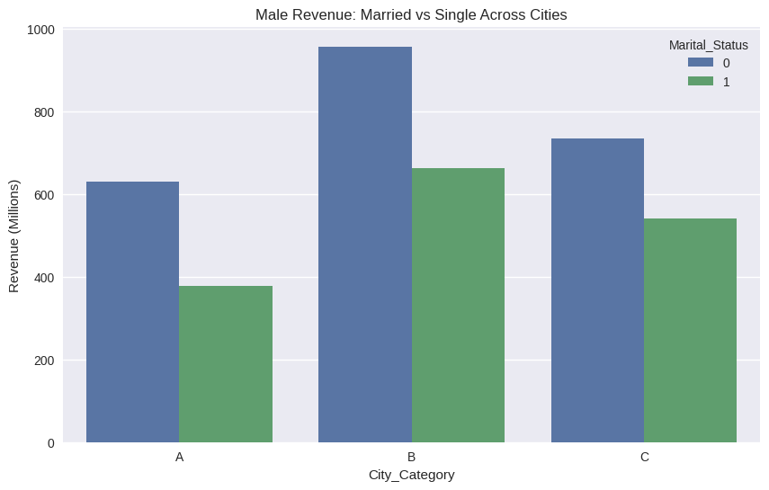

```python
plt.figure(figsize=(10,6))

sns.barplot(
    data=marital_status_males_df,
    x='City_Category',
    y='Purchase',
    hue='Marital_Status'
)

plt.title('Male Revenue: Married vs Single Across Cities')
plt.ylabel('Revenue (Millions)')

for container in ax.containers:
  ax.bar_label(container)

plt.show()
```

```python
marital_status_females_df = females.groupby(['City_Category', 'Marital_Status']).agg({'User_ID': 'count', 'Purchase': 'sum'}).reset_index()
marital_status_females_df['Purchase'] = marital_status_females_df['Purchase'].apply(millions).astype(float)
marital_status_females_df
```

|  | City_Category | Marital_Status | User_ID | Purchase |
| --- | --- | --- | --- | --- |
| 0 | A | 0 | 21827 | 187.27 |
| 1 | A | 1 | 13877 | 119.06 |
| 2 | B | 0 | 34527 | 292.81 |
| 3 | B | 1 | 23269 | 200.81 |
| 4 | C | 0 | 22467 | 204.08 |
| 5 | C | 1 | 19842 | 182.21 |

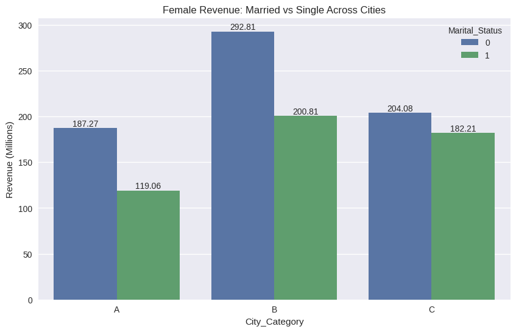

```python
plt.figure(figsize=(10,6))

ax = sns.barplot(
    data=marital_status_females_df,
    x='City_Category',
    y='Purchase',
    hue='Marital_Status'
)

plt.title('Female Revenue: Married vs Single Across Cities')
plt.ylabel('Revenue (Millions)')

for container in ax.containers:
  ax.bar_label(container)

plt.show()
```

### Single users dominate the platform across both genders and all cities, contributing significantly higher revenue. This indicates that marketing strategies should primarily target unmarried individuals, especially in high-performing cities like City B.